# PEC 1 MO.157- Análisis de datos Ómicos. Rubén Jové Nieto

El estudio de dónde se han obtenido las muestras es el siguiente (1): Galicia, J. C., Henson, B. R., Parker, J. S., & Khan, A. A. (2016). Gene expression profile of pulpitis. Genes and immunity, 17(4), 239–243. https://doi.org/10.1038/gene.2016.14

Enlace al repositorio de github.

https://github.com/rbenjn/PEC_01

## Abstract

Las enfermedades endodónticas presentan una prevalencia, coste y dolor que requiere de una mayor comprensión de los aspectos moleculares fundamentales de su patogénesis. Las pulpas inflamadas se recogieron de pacientes diagnosticados con pulpitis irreversible (n=20) y las pulpas normales sirvieron como controles (n=20). El dolor de valoró con la EVA. El análisis de microarrays con Affymetrix GeneTitan Multichannel Instrument. Como resultado, hubo una mayor expresión de genes involucrados en la respuesta inmune en el grupo de pulpitis. En cuanto a dolor, varios genes de lo modulan junto con la inflamación, mostraron una expresión diferencial en pacientes con dolor leve vs intenso.

## Objetivos

El objetivo de este estudio es idenftificar a nivel genético, los factores que contribuyen al dolor e inflamación pulpar o pulpitis. También así poder proporcionar una base molecular para el diagnóstico clínico de pulpitis. Al comprender de mejor manera la inflamación pulpar, posteriores estudios sobre el tratamiento y manejo de la pulpitis y dolor asociado, pueden tener una referencia biológica.

## Materiales y métodos

El estudio fue aprobado por la Oficina Ética de la Universidad de Carolina del Norte. Los datos provienen de pacientes que se trataban en la Escuela de Odontologia. Los criterios de inclusión fueron adultos que se presentaron para tratamiento endodóntico sin evidencia de patologías periapicales y sin terapia pulpar previa. Se excluyó a aquellos que tomaban debido a otras patologias o motivos, medicamentos de acción central que interfieren en la liberación de mediadores del dolor y/o alteran la respuesta inmune. El dolor fue valorado con la escala visual análogica (EVA). Clasificando las puntuaciones en: menos de 30 leve, 31-74 moderado y 75-100 dolor intenso. Se realizaron 2 grupos, uno de casos y el otro de controles. Las pulpas inflamadas se recogieron de pacientes diagnosticados con pulpitis irreversible (n=20) y las pulpas normales sirvieron como controles (n=20).

Se realizarán dos comparaciones, por un lado pulpas normales vs inflamadas (6vs6). Por otro lado, dentro de las inflamadas, se comparará el dolor: leve vs severo (3vs3).

### “Pipeline” análisis

Los pasos o “pipeline” seguido para el análisis han sido:

1. Identificar que grupos hay y a qué grupo pertenece cada muestra.
2. Control de calidad de los datos crudos
3. Normalización
4. Control de calidad de los datos normalizados
5. Filtraje no específico
6. Identificación de genes diferencialmente expresados
7. Anotación de los resultados
8. Comparación entre distintas comparaciones
9. Análisis de significación biológica (“Gene Enrichment Analysis”)

### “Pipeline” ampliada

#### 1. Identificar que grupos hay y a qué grupo pertenece cada muestra.

Accedemos al Accession Display de GSE77459. En su parte inferior podemos ver los Samples (12) con sus GSM y así saber a qué grupo pertenece cada muestra: normal o inflammed, intensidad de dolor leve o severa. A partir de eso, crearemos el archivo targets.csv, dónde identificaremos cada muestra según su grupo.

Contenido del archivo targets utilizado para el análisis

| FileName | Group | Genotype | Pain | ShortName |
| --- | --- | --- | --- | --- |
| GSM2052371_1 | Normal.Ninguno | Normal | Ninguno | N.N.1 |
| GSM2052372_2 | Normal.Ninguno | Normal | Ninguno | N.N.2 |
| GSM2052373_3 | Normal.Ninguno | Normal | Ninguno | N.N.3 |
| GSM2052374_4 | Normal.Ninguno | Normal | Ninguno | N.N.4 |
| GSM2052375_5 | Normal.Ninguno | Normal | Ninguno | N.N.5 |
| GSM2052376_6 | Normal.Ninguno | Normal | Ninguno | N.N.6 |
| GSM2052377_7 | Inflammed.Leve | Inflammed | Leve | I.L.1 |
| GSM2052378_8 | Inflammed.Leve | Inflammed | Leve | I.L.2 |
| GSM2052379_9 | Inflammed.Leve | Inflammed | Leve | I.L.3 |
| GSM2052380_10 | Inflammed.Severo | Inflammed | Severo | I.S.4 |
| GSM2052381_11 | Inflammed.Severo | Inflammed | Severo | I.S.5 |
| GSM2052382_12 | Inflammed.Severo | Inflammed | Severo | I.S.6 |

#### 2. Control de calidad de los datos crudos

Con el paquete “arrayQualityMetrics” podemos verificar si los arrays obtenidos son de buena cualidad. Según los resultados obtenidos, los mantendríamos o no en el análisis.

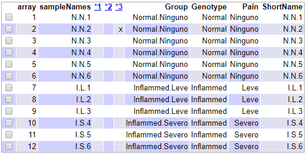

Tabla Control Calidad de los Datos Crudos

En nuestro caso, los resultados obtenidos como se muestra en la imagen, permiten mantener todos los arrays en el análisis. Sólo el número 2 ha sido marcado, pero sólo en una ocasión. Lo cuál indica que los problemas potenciales serán pequeños.

Mostramos en gráfico el análisis del componente y observamos como se distribuyen en función de su grupo, denotando unas diferencias:

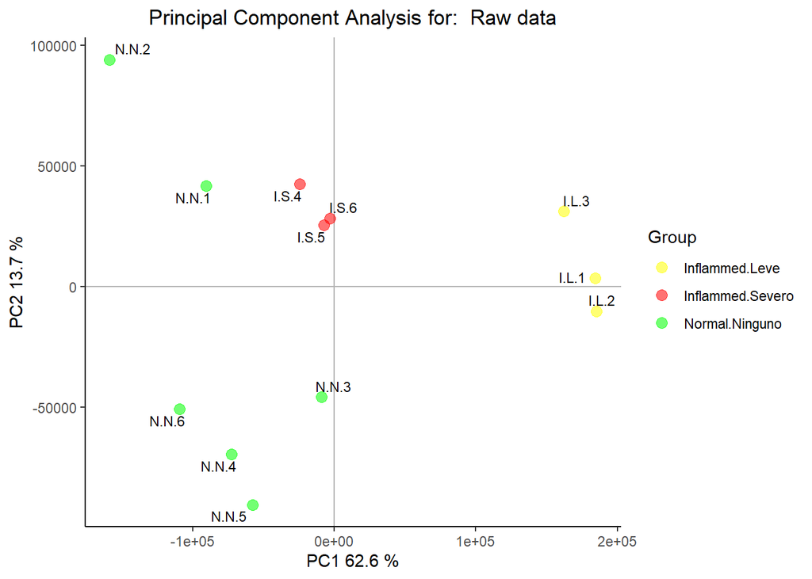

También mediante boxplot podemos visualizar la intensidad de la distribución:

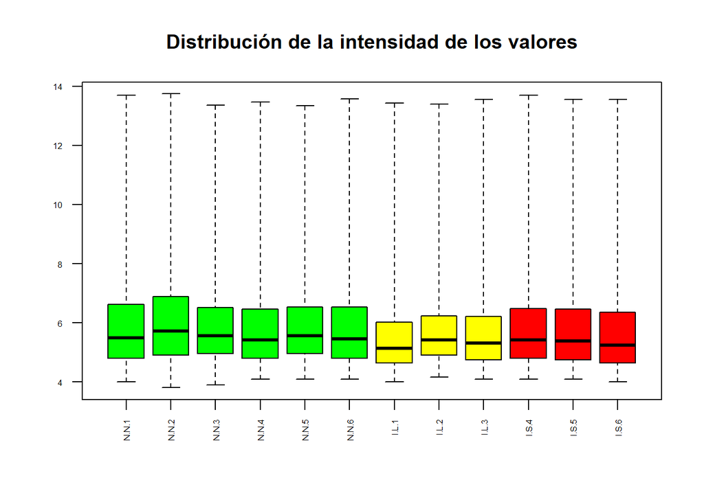

#### 3. Normalización

Para normalizar los datos, usamos el método Robust Multichip Analysis.

#### 4. Control de calidad de los datos normalizados

Realizamos procedimiento que hemos llevado a cabo antes pero con los datos normalizados. Usaremos la función arrayQualityMetrics de la misma manera:

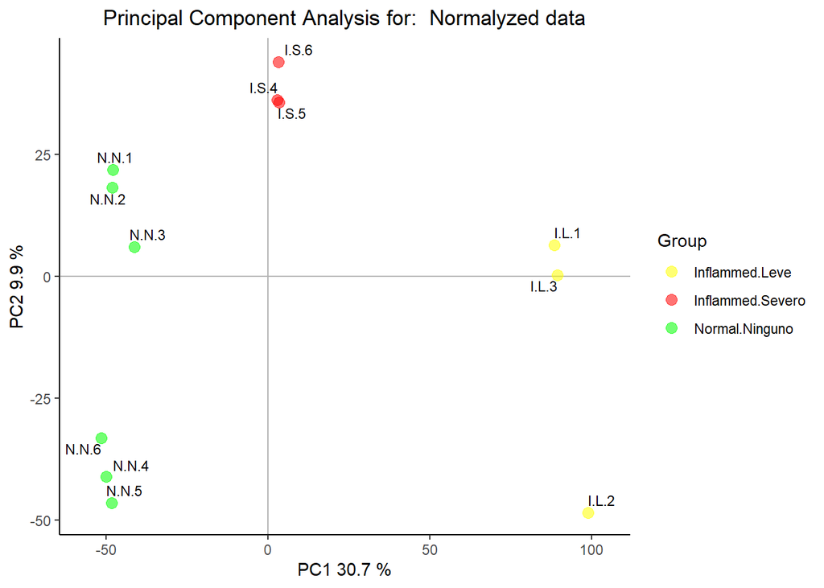

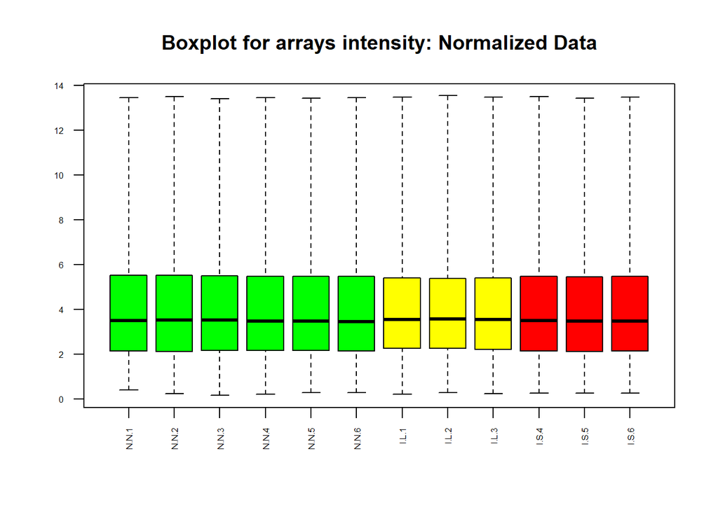

En el Boxplot observamos los datos ya normalizados, a diferencia del Boxplot del apartado 2.

#### 5. Filtraje no específico

Detectamos los pequeños cambios que se dan al procesar las muestras observando su varianza. Utilizamos el paquete “pvca”.

Mostramos un gráfico que nos muestra cuáles variables muestran más varianza, en este caso la variable Genotipo:

```
## boundary (singular) fit: see ?isSingular
## boundary (singular) fit: see ?isSingular
## boundary (singular) fit: see ?isSingular
## boundary (singular) fit: see ?isSingular
```

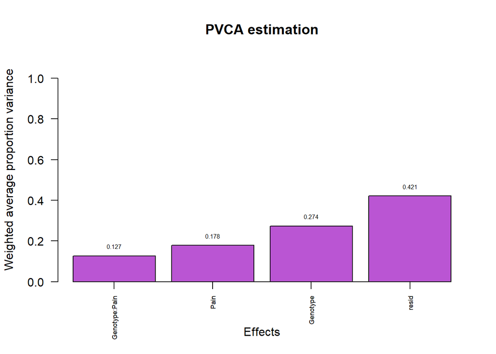

#### 6. Identificación de genes diferencialmente expresados

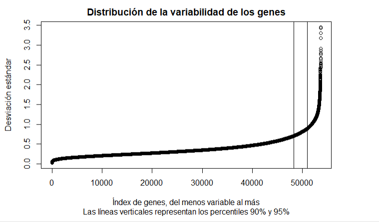

Distribución de la variabilidad de los genes

Los genes con una mayor variabilidad se encuentran con una desviación estándar por encima del 90-95% de todas las desviaciones estándar.

A continuación, con la función “nsFilter” del paquete de BioConductor “genefilter” filtramos los genes con poca variabilidad y que por lo tanto no tienen una expresión diferencial.

```
## $numDupsRemoved
## [1] 2829
##
## $numLowVar
## [1] 19738
##
## $numRemoved.ENTREZID
## [1] 24470
```

Quedan 6580 genes filtrados.

#### 7. Anotación de los resultados

Creamos las matrices de diseño para realizar las posteriores comparaciones entre grupos:

```
##    I.L I.S N.N
## 1    0   0   1
## 2    0   0   1
## 3    0   0   1
## 4    0   0   1
## 5    0   0   1
## 6    0   0   1
## 7    1   0   0
## 8    1   0   0
## 9    1   0   0
## 10   0   1   0
## 11   0   1   0
## 12   0   1   0
## attr(,"assign")
## [1] 1 1 1
## attr(,"contrasts")
## attr(,"contrasts")$Group
## [1] "contr.treatment"
```

A continuación definimos las comparaciones con las matrices de contraste:

```
##       Contrasts
## Levels InflammedvsNormal I.LvsI.S
##    I.L                 1        1
##    I.S                 1       -1
##    N.N                -1        0
```

Estimamos el modelo y la selección de genes con el paquete “limma”:

Posteriormente, otbenemos una lista con los genes con mayor expresión diferencial.

Mostramos la cabecera para las 2 comparaciones.

En primer lugar, para la comparación Inflamado vs Normal

|  | logFC | AveExpr | t | P.Value | adj.P.Val | B |
| --- | --- | --- | --- | --- | --- | --- |
| 16693414 | 12.05599 | 10.129853 | 84.53948 | 3.177221e-18 | 9.581665e-15 | 26.45255 |
| 16671139 | 12.30590 | 9.593264 | 82.93421 | 4.010337e-18 | 9.581665e-15 | 26.37938 |
| 16712272 | 11.51708 | 12.134091 | 82.35211 | 4.368540e-18 | 9.581665e-15 | 26.35199 |
| 17063254 | 10.97504 | 11.766863 | 78.46616 | 7.857653e-18 | 1.104801e-14 | 26.15667 |
| 16859763 | 12.30778 | 8.686143 | 78.03981 | 8.395146e-18 | 1.104801e-14 | 26.13383 |
| 17126266 | 11.92108 | 11.013317 | 73.39414 | 1.768824e-17 | 1.409511e-14 | 25.86473 |

En este caso, para la comparación de Dolor entre muestras del grupo Inflamado:

|  | logFC | AveExpr | t | P.Value | adj.P.Val | B |
| --- | --- | --- | --- | --- | --- | --- |
| 16882555 | 2.649697 | 8.121571 | 17.31203 | 6.133384e-10 | 4.035767e-06 | 13.06798 |
| 17110670 | 2.439695 | 4.651897 | 15.79809 | 1.786757e-09 | 5.878431e-06 | 12.12189 |
| 17017885 | 2.182432 | 6.943299 | 14.53149 | 4.709305e-09 | 9.515255e-06 | 11.24050 |
| 16682785 | 3.674498 | 3.372725 | 14.02292 | 7.101155e-09 | 9.515255e-06 | 10.86076 |
| 16689400 | 2.287339 | 5.267487 | 14.00095 | 7.230437e-09 | 9.515255e-06 | 10.84400 |
| 16976827 | 3.542751 | 5.027086 | 13.43985 | 1.156302e-08 | 9.613389e-06 | 10.40555 |

Visualizamos los genes expresado de manera distinta mediante un volcano plot:

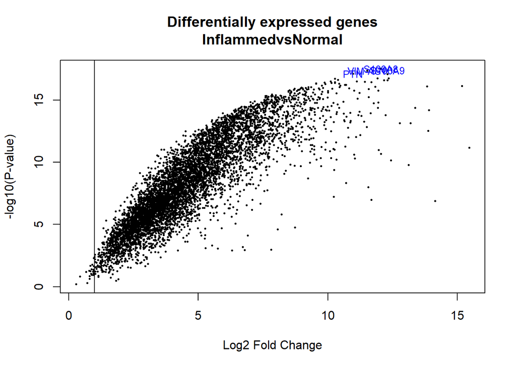

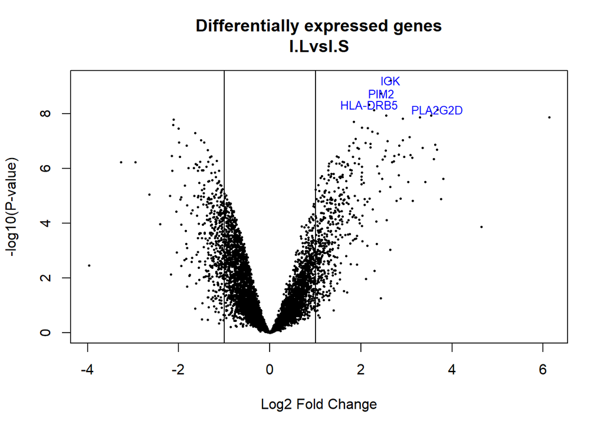

En el volcano plot mostramos los nombres de los 4 genes expresados de de mayor manera diferencial. Observamos las diferencias entre grupos según el gráfico obtenido. Distinto entre las 2 comparaciones, debido a sus diferencias de grupo.

#### 8. Comparación entre distintas comparaciones

Realizamos las múltiples comparaciones:

```
##        InflammedvsNormal I.LvsI.S
## Down                   0      366
## NotSig                27     5756
## Up                  6553      458
```

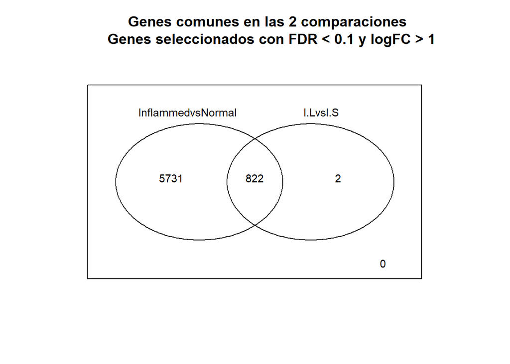

El Diagrama de Venn nos muestra los genes comunes entre las 2 comparaciones. Un total de 822

Los Mapas de Calor:

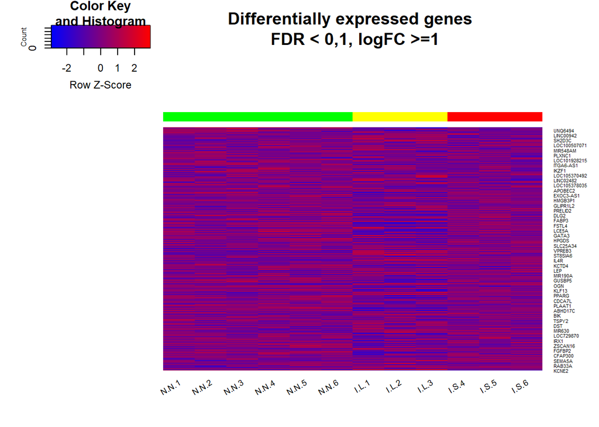

#### 9. Análisis de significación biológica (“Gene Enrichment Analysis”)

Preparamos lista de genes analizados

```
## InflammedvsNormal          I.LvsI.S
##              6551              2020
```

Los genes a tener en cuenta, tienen al menos una anotación en Gene Ontology.

Tabla Inflamado vs Normal

| ID | Description | GeneRatio | BgRatio | pvalue | p.adjust | qvalue | geneID | Count |
| --- | --- | --- | --- | --- | --- | --- | --- | --- |
| hsa04640 | Hematopoietic cell lineage | 61/1841 | 98/7991 | 7.75703789476954e-17 | 2.48225212632625e-14 | 2.05765636787571e-14 | 3554/4311/3119/1604/3815/3109/3563/915/3123/4254/3566/951/14…… | 61 |
| hsa04060 | Cytokine-cytokine receptor interaction | 126/1841 | 294/7991 | 1.27065310331772e-14 | 2.03304496530836e-12 | 1.68528727387403e-12 | 7852/3554/6352/6347/7040/654/5473/2920/3563/6387/3566/1441/3…… | 126 |
| hsa05323 | Rheumatoid arthritis | 54/1841 | 92/7991 | 1.57873150510695e-13 | 1.68398027211408e-11 | 1.39593101504194e-11 | 1513/3119/6352/6347/7040/3109/2920/6387/3123/3127/3122/3115/…… | 54 |
| hsa04061 | Viral protein interaction with cytokine and cytokine receptor | 55/1841 | 100/7991 | 3.68780810401393e-12 | 2.95024648321114e-10 | 2.44559905845134e-10 | 7852/6352/6347/5473/2920/6387/8743/3587/6362/3561/6366/1233/…… | 55 |
| hsa05332 | Graft-versus-host disease | 30/1841 | 41/7991 | 1.27972801230647e-11 | 8.1902592787614e-10 | 6.78929387581537e-10 | 3133/3119/3109/3123/3127/3122/3115/3135/3125/3108/3107/3113/3105/942/941/3111/3569/3553/3126/3106/7124/3117/3002/5551/3824/356/3458/3552/940/3812 | 30 |
| hsa05150 | Staphylococcus aureus infection | 51/1841 | 93/7991 | 2.61812481736328e-11 | 1.39633323592708e-09 | 1.15748676136061e-09 | 2357/3119/3109/3123/3127/2359/3122/3115/714/3125/3108/713/64…… | 51 |

Tabla Dolor

| ID | Description | GeneRatio | BgRatio | pvalue | p.adjust | qvalue | geneID | Count |
| --- | --- | --- | --- | --- | --- | --- | --- | --- |
| hsa05323 | Rheumatoid arthritis | 36/717 | 92/7991 | 3.20304563264605e-15 | 1.00575632865086e-12 | 7.95703967688913e-13 | 3127/6374/6364/6348/6349/3123/3553/941/3683/2920/7124/6352/3119/3552/1493/942/3109/7040/3689/10673/3115/4050/1513/3383/3458/2921/2353/3576/3122/3111/525/3108/7097/2321/245972/6347 | 36 |
| hsa04060 | Cytokine-cytokine receptor interaction | 67/717 | 294/7991 | 2.80614605621923e-13 | 4.4056493082642e-11 | 3.48552878561968e-11 | 6374/608/6364/6348/10563/6349/6362/3553/7852/3557/5008/1233/…… | 67 |
| hsa04062 | Chemokine signaling pathway | 49/717 | 189/7991 | 3.64046978404517e-12 | 3.81035837396728e-10 | 3.0145644527532e-10 | 6374/6364/6348/10563/6349/6362/7852/5330/3055/1233/1794/2770…… | 49 |
| hsa04640 | Hematopoietic cell lineage | 33/717 | 98/7991 | 6.42509396696605e-12 | 5.04369876406835e-10 | 3.99032151632629e-10 | 3127/3123/915/3553/3673/931/951/3575/7124/3119/3552/916/948/914/1441/3109/917/4254/3115/930/3554/290/3122/3690/3111/3108/960/3590/1438/920/926/7850/952 | 33 |
| hsa05332 | Graft-versus-host disease | 20/717 | 41/7991 | 3.89329285797259e-11 | 2.44498791480679e-09 | 1.93435181996112e-09 | 3127/3123/3553/941/7124/3119/3552/942/3109/3115/3458/3122/3135/3111/3108/3824/3106/5551/3002/3107 | 20 |
| hsa04380 | Osteoclast differentiation | 35/717 | 127/7991 | 8.03170461635628e-10 | 4.20325874922645e-08 | 3.32540752536856e-08 | 3553/3937/7124/29760/3552/4688/11006/7040/1513/3554/3458/695/4689/5293/6850/2353/2213/3455/2212/11024/3690/10326/54209/3932/4982/5971/7305/11027/5336/5600/140885/3726/5599/126014/5290 | 35 |

Los datos al completo los encotramos almacenados en los respectivos archivos .csv para cada comparación.

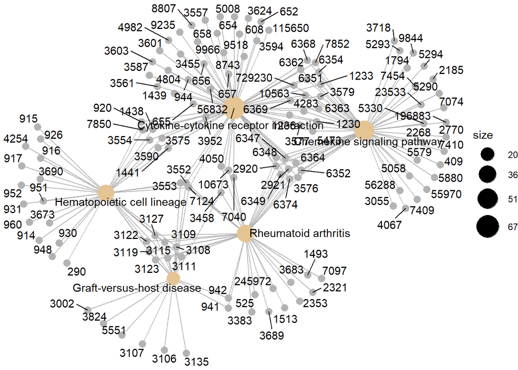

## Resultados

Obtenemos resultados significativos de ambas comparaciones.

### Muestra Normal vs Muestra Pulpitis

El Gene Set Enrichment Analysis mostró genes que se expresan de manera diferencial. Con una mayor expresión en la muestra de Pulpitis de genes asociados con la activación de la respuesta inmunitaria.

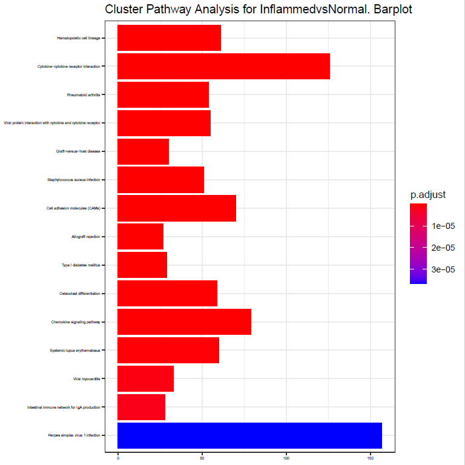

Barplot Genes expresados diferencialmente Normal vs Pulpitis

#### Muestra Dolor Leve vs Dolor Severo

Entre las personas que referían dolor (3 severo y 3 leve), encontramos genes expresados de forma diferencial entre los 2 grupos. Con especial atención a aquellos genes relacionados con el sistema inmune adaptativo y la interacción citoquina-citoquina.

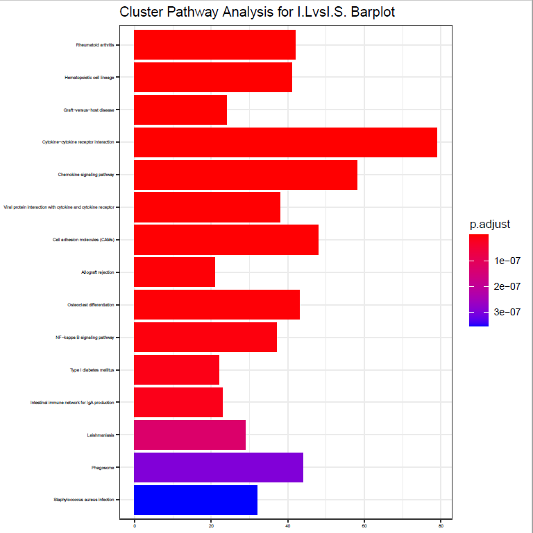

Barplot Genes expresados diferencialmente Dolor Leve vs Dolor Severo

## Discusión

Aunque el uso del análisis de microarrays es una herramienta poderosa para estudiar la expresión simultánea de varios genes, hay algunas limitaciones.

Por ejemplo, factores técnicos como el rango limitado y la hibridización cruzada. Además el perfil celular de las pulpas inflamadas difiere de las normales. En las inflamadas se caracterizan por tener una afluencia ya por encima de lo normal de células inmunes.

Es decir, que los resultados pueden ser en parte debido a diferencias en la composición celular.

## Apéndice

Enlace al repositorio de github, dónde se halla el código R utilizado entre los otros archivos del estudio.

https://github.com/rbenjn/PEC_01

## Bibliografía

1. Galicia, J. C., Henson, B. R., Parker, J. S., & Khan, A. A. (2016). Gene expression profile of pulpitis. Genes and immunity, 17(4), 239–243. https://doi.org/10.1038/gene.2016.14
2. Yu, Guangchuang, and Qing-Yu He. 2016. “ReactomePA: An R/Bioconductor Package for Reactome Pathway Analysis and Visualization.” Molecular BioSystems 12 (2): 477–79. https://doi.org/10.1039/C5MB00663E.
3. Yu, Guangchuang, Li-Gen Wang, Guang-Rong Yan, and Qing-Yu He. 2015. “DOSE: An R/Bioconductor Package for Disease Ontology Semantic and Enrichment Analysis.” Bioinformatics 31 (4): 608–9. https://doi.org/10.1093/bioinformatics/btu684.